# (What factors that affect on your Churn)

## by (Abrar Ali Mohammed)

## Investigation Overview

> Analysis features for Telco customers to obtain which factors affect on their churn.

## Dataset Overview

> These data includes information about 7043 customers for phone company that want to analysis what factors that affect on customers to churn to another company and obtains 21 different characteristics of their phone serveces and their fetures compared to if they churn or not.Varibles include Phone Service, Internet Service, TechSupport, Payment Method, contract, TotalCharges and others.

## churn percentage

> The ratio of churn customers is approxmetly 27 % of total customers , these ratio it will be analysised with other data factors.

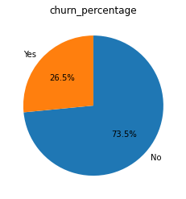

## Does Contract effect on Churn customers?

> We observed here that Month to month contract have the highest churn ratio , it observed that Month to month contract affect on churn percentage and there is a relationship.

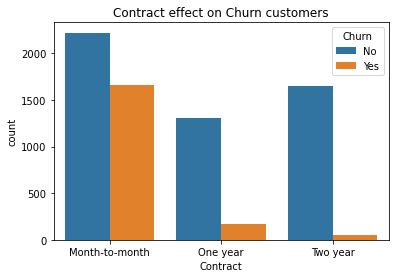

## Does Internet Service effect on Churn customers?

> We observed here that fiber optic internet service have the highest churn ratio although it have high number of customers becouse it is faster, DSL have low churn ratio.so we can ask here WHY?

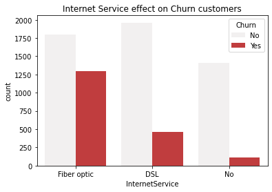

## Does Payment Method effect on Churn customers?

> Electronic check Payment Method observed that have the highest churn ratio although all other factors have the same number of non churn customers.

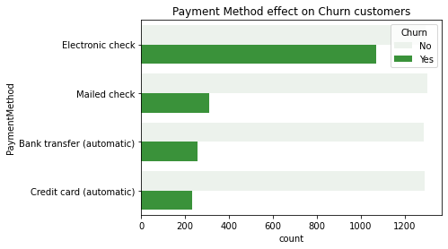

## Factors effect which compaied with each other

Customers that have both Electronic check Payment Method and fiber optic internet service have the highest churn ratio.

> And fiber optic internet service affect on others factors assoiated with related to churn ratio. As well as Electronic check Payment Method

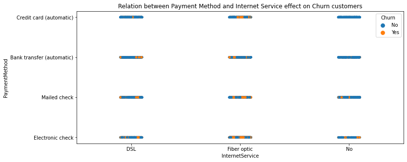